# Example: Parkinson’s disease

### Further results

For comparison with Dias et al. (2011), we can produce relative effects against placebo using the `relative_effects()` function with `trt_ref = 1`:

```r
(mix_releff_FE <- relative_effects(mix_fit_FE, trt_ref = 1))
```

```
#>       mean   sd  2.5%   25%   50%   75% 97.5% Bulk_ESS Tail_ESS Rhat
#> d[4] -0.52 0.49 -1.47 -0.84 -0.52 -0.21  0.44     1363     2048    1
#> d[2] -1.81 0.33 -2.46 -2.02 -1.80 -1.59 -1.18     5123     3207    1
#> d[3] -0.48 0.49 -1.41 -0.81 -0.48 -0.16  0.51     2184     2650    1
#> d[5] -0.82 0.53 -1.84 -1.17 -0.82 -0.48  0.22     1481     2245    1
```

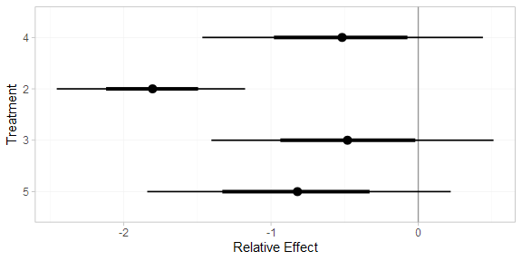

```r
plot(mix_releff_FE, ref_line = 0)
```

```r
(mix_releff_RE <- relative_effects(mix_fit_RE, trt_ref = 1))
```

```
#>       mean   sd  2.5%   25%   50%   75% 97.5% Bulk_ESS Tail_ESS Rhat
#> d[4] -0.52 0.59 -1.60 -0.90 -0.53 -0.15  0.62     1972     1909    1
#> d[2] -1.84 0.46 -2.73 -2.11 -1.84 -1.58 -0.97     4337     2612    1
#> d[3] -0.49 0.59 -1.62 -0.86 -0.49 -0.13  0.67     3171     2830    1
#> d[5] -0.81 0.70 -2.14 -1.24 -0.82 -0.39  0.55     2047     2273    1
```

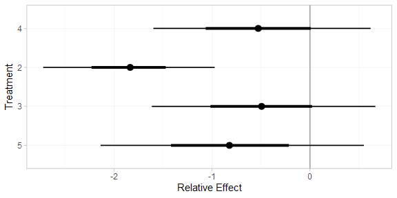

```r
plot(mix_releff_RE, ref_line = 0)
```

Following Dias et al. (2011), we produce absolute predictions of the mean off-time reduction on each treatment assuming a Normal distribution for the outcomes on treatment 1 (placebo) with mean $-0.73$ and precision $21$. We use the `predict()` method, where the `baseline` argument takes a `distr()` distribution object with which we specify the corresponding Normal distribution, and we specify `trt_ref = 1` to indicate that the baseline distribution corresponds to treatment 1. (Strictly speaking, `type = "response"` is unnecessary here, since the identity link function was used.)

```r
mix_pred_FE <- predict(mix_fit_FE,
                       baseline = distr(qnorm, mean = -0.73, sd = 21^-0.5),
                       type = "response",
                       trt_ref = 1)
mix_pred_FE
```

```
#>          mean   sd  2.5%   25%   50%   75% 97.5% Bulk_ESS Tail_ESS Rhat
#> pred[4] -1.25 0.54 -2.30 -1.60 -1.24 -0.89 -0.19     1548     2511    1
#> pred[1] -0.72 0.22 -1.14 -0.87 -0.72 -0.58 -0.30     3607     3552    1
#> pred[2] -2.53 0.39 -3.31 -2.78 -2.53 -2.27 -1.76     4294     3435    1
#> pred[3] -1.20 0.53 -2.25 -1.56 -1.21 -0.84 -0.14     2287     2807    1
#> pred[5] -1.55 0.57 -2.66 -1.93 -1.55 -1.16 -0.41     1641     2742    1
```

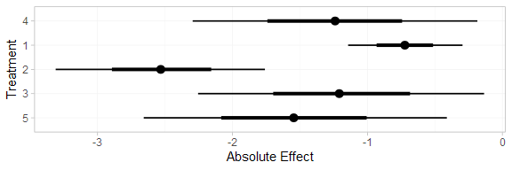

```r
plot(mix_pred_FE)
```

```r
mix_pred_RE <- predict(mix_fit_RE,
                       baseline = distr(qnorm, mean = -0.73, sd = 21^-0.5),
                       type = "response",
                       trt_ref = 1)
mix_pred_RE
```

```
#>          mean   sd  2.5%   25%   50%   75% 97.5% Bulk_ESS Tail_ESS Rhat
#> pred[4] -1.25 0.63 -2.43 -1.66 -1.26 -0.84  0.03     2126     2421    1
#> pred[1] -0.73 0.22 -1.17 -0.88 -0.73 -0.58 -0.31     3923     3771    1
#> pred[2] -2.57 0.51 -3.58 -2.89 -2.57 -2.26 -1.57     4247     3078    1
#> pred[3] -1.22 0.63 -2.44 -1.63 -1.22 -0.82  0.01     3317     3083    1
#> pred[5] -1.54 0.73 -2.95 -2.00 -1.55 -1.10 -0.05     2117     2100    1
```

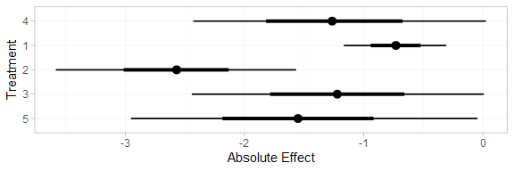

```r
plot(mix_pred_RE)
```

If the `baseline` argument is omitted, predictions of mean off-time reduction will be produced for every *arm-based* study in the network based on their estimated baseline response $\mu_j$:

```r
mix_pred_FE_studies <- predict(mix_fit_FE, type = "response")
mix_pred_FE_studies
```

```
#> ---------------------------------------------------------------------- Study: 1 ----
#>
#>             mean   sd  2.5%   25%   50%   75% 97.5% Bulk_ESS Tail_ESS Rhat
#> pred[1: 4] -1.64 0.46 -2.53 -1.94 -1.65 -1.34 -0.75     1853     2347    1
#> pred[1: 1] -1.12 0.43 -1.96 -1.40 -1.12 -0.83 -0.29     3344     2988    1
#> pred[1: 2] -2.93 0.51 -3.94 -3.27 -2.93 -2.58 -1.94     3005     3091    1
#> pred[1: 3] -1.60 0.40 -2.37 -1.87 -1.60 -1.33 -0.81     3486     2937    1
#> pred[1: 5] -1.94 0.50 -2.94 -2.28 -1.94 -1.61 -0.94     1913     2600    1
#>
#> ---------------------------------------------------------------------- Study: 2 ----
#>
#>             mean   sd  2.5%   25%   50%   75% 97.5% Bulk_ESS Tail_ESS Rhat
#> pred[2: 4] -1.17 0.52 -2.19 -1.50 -1.18 -0.82 -0.16     1341     1904    1
#> pred[2: 1] -0.65 0.26 -1.15 -0.82 -0.65 -0.47 -0.13     4641     3786    1
#> pred[2: 2] -2.45 0.24 -2.93 -2.61 -2.45 -2.30 -2.00     4785     3399    1
#> pred[2: 3] -1.12 0.53 -2.14 -1.48 -1.12 -0.78 -0.08     2022     2542    1
#> pred[2: 5] -1.47 0.56 -2.56 -1.85 -1.47 -1.10 -0.37     1450     2148    1
#>
#> ---------------------------------------------------------------------- Study: 3 ----
#>
#>             mean   sd  2.5%   25%   50%   75% 97.5% Bulk_ESS Tail_ESS Rhat
#> pred[3: 4] -1.11 0.42 -1.93 -1.39 -1.11 -0.84 -0.30     1612     2208    1
#> pred[3: 1] -0.59 0.36 -1.28 -0.84 -0.59 -0.35  0.11     3775     3411    1
#> pred[3: 2] -2.40 0.38 -3.15 -2.65 -2.39 -2.15 -1.65     3639     3500    1
#> pred[3: 3] -1.07 0.46 -1.96 -1.38 -1.07 -0.76 -0.15     2742     2707    1
#> pred[3: 5] -1.41 0.47 -2.32 -1.73 -1.42 -1.11 -0.46     1813     2512    1
```

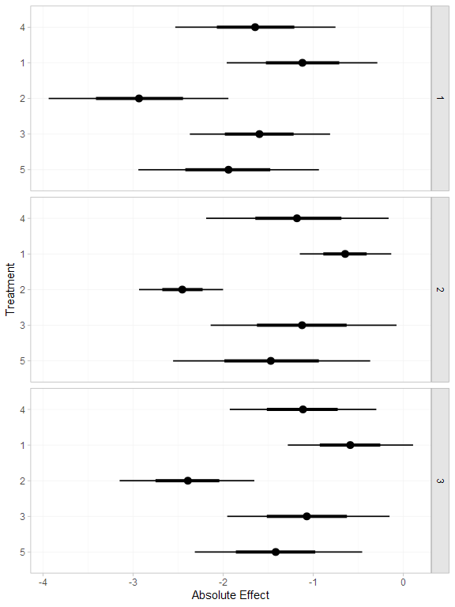

```r
plot(mix_pred_FE_studies)
```

We can also produce treatment rankings, rank probabilities, and cumulative rank probabilities.

```r
(mix_ranks <- posterior_ranks(mix_fit_FE))
```

```
#>         mean   sd 2.5% 25% 50% 75% 97.5% Bulk_ESS Tail_ESS Rhat
#> rank[4] 3.50 0.70    2   3   3   4     5     1952       NA    1
#> rank[1] 4.64 0.79    2   5   5   5     5     2047       NA    1
#> rank[2] 1.05 0.27    1   1   1   1     2     2460     2523    1
#> rank[3] 3.52 0.92    2   3   4   4     5     3231       NA    1
#> rank[5] 2.29 0.68    1   2   2   2     4     2284     2195    1
```

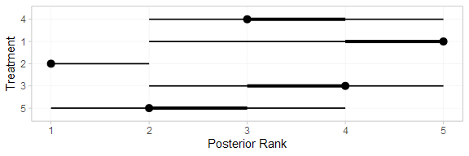

```r
plot(mix_ranks)
```

```r
(mix_rankprobs <- posterior_rank_probs(mix_fit_FE))
```

```
#>      p_rank[1] p_rank[2] p_rank[3] p_rank[4] p_rank[5]
#> d[4]      0.00      0.04      0.49      0.39      0.07
#> d[1]      0.00      0.04      0.06      0.10      0.79
#> d[2]      0.96      0.03      0.01      0.00      0.00
#> d[3]      0.00      0.17      0.26      0.45      0.12
#> d[5]      0.04      0.72      0.18      0.05      0.01
```

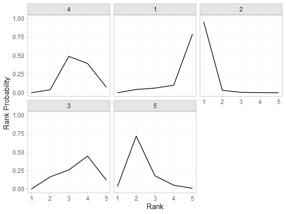

```r
plot(mix_rankprobs)
```

```r
(mix_cumrankprobs <- posterior_rank_probs(mix_fit_FE, cumulative = TRUE))
```

```
#>      p_rank[1] p_rank[2] p_rank[3] p_rank[4] p_rank[5]
#> d[4]      0.00      0.04      0.53      0.93         1
#> d[1]      0.00      0.04      0.11      0.21         1
#> d[2]      0.96      0.99      1.00      1.00         1
#> d[3]      0.00      0.17      0.43      0.88         1
#> d[5]      0.04      0.75      0.93      0.99         1
```

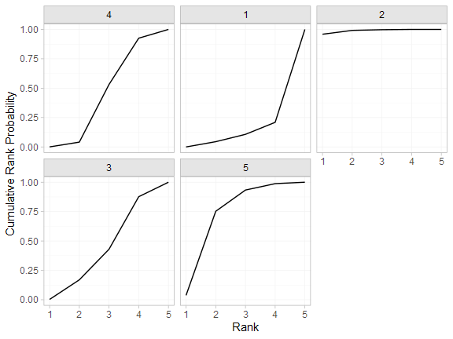

```r
plot(mix_cumrankprobs)
```

## References

Dias, S., N. J. Welton, A. J. Sutton, and A. E. Ades. 2011. “NICE DSU Technical Support Document 2: A Generalised Linear Modelling Framework for Pair-Wise and Network Meta-Analysis of Randomised Controlled Trials.” National Institute for Health and Care Excellence. http://nicedsu.org.uk/.